# Survey Deoccupied Hromadas

# 7. IDP

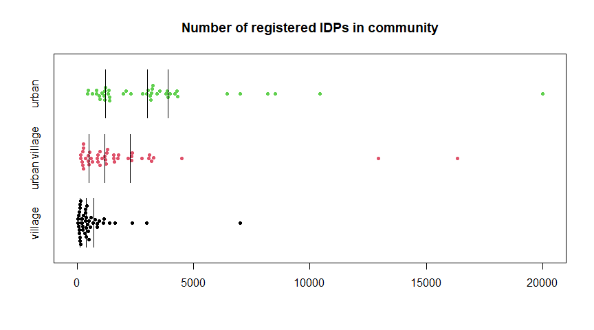

```r
d <- ds0 %>% filter(idp_accept == 'yes') %>%
  select(hromada_code, idp_registration_number, type)

beeswarm(d$idp_registration_number ~ d$type,  method='swarm',
         main = 'Number of registered IDPs in community', xlab = NA, ylab = NA,
         pwcol= d$type, pch = 19, cex = 0.7,
         horizontal = TRUE, corral = 'random')
# axis(1, at=seq(0, 200, by = 10), las=2)
bxplot(d$idp_registration_number ~ d$type, horizontal = TRUE, add = TRUE, lwd = 1.2)
```

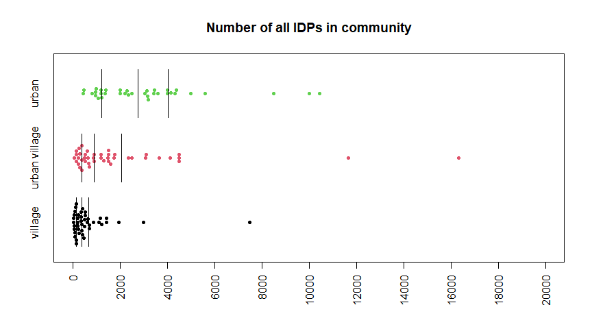

```r
d <- ds0 %>% filter(idp_accept == 'yes') %>%
  select(hromada_code, idp_real_number, type)

beeswarm(d$idp_real_number ~ d$type,  method='swarm',
         main = 'Number of all IDPs in community', xlab = NA, ylab = NA,
         pwcol= d$type, pch = 19, cex = 0.7,
         xlim = c(0, 20000),
         horizontal = TRUE, corral = 'random', xaxt="n")
axis(1, at=seq(0, 20000, by = 2000), las=2)
bxplot(d$idp_real_number ~ d$type, horizontal = TRUE, add = TRUE, lwd = 1.2)
```

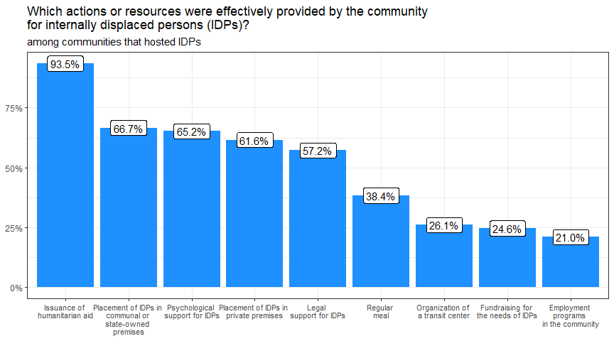

```r
help_idp_levels <- c('communal_placement', 'private_placement', 'regular_meal', 'humanitar_help',
                     'fundraising', "employ", "psych_help", "law_help", "transit_center")

d <- ds0 %>% select(hromada_code, starts_with('idp_help/'), -ends_with('number')) %>%
  pivot_longer(-hromada_code, names_to = 'help', values_to = 'count') %>%
  count(help, count) %>% group_by(help) %>%
  mutate(freq = n/sum(n),
         help = str_remove(help, 'idp_help/')) %>%
  filter(count == 1)

p <- d %>%
  ggplot(aes(x = fct_reorder(factor(help), freq, .desc = TRUE), y = freq)) +
  geom_col(fill = "dodgerblue") +
  geom_label(aes(label = scales::percent(freq)))  +
  theme_bw() +
  theme(axis.title.y = element_blank(),
        axis.title.x = element_blank(),
        axis.text.x = element_text(size = 8)) +
  labs(title = 'Which actions or resources were effectively provided by the community \nfor internally displaced persons (IDPs)?',
       subtitle = "among communities that hosted IDPs",) +
  scale_y_continuous(labels = scales::percent) +
  scale_x_discrete(labels=c('communal_placement' = "Placement of IDPs in \ncommunal or \nstate-owned \npremises",
                            'private_placement' = "Placement of IDPs in \nprivate premises",
                            'regular_meal' = "Regular \nmeal",
                            'humanitar_help' = "Issuance of \nhumanitarian aid",
                            'fundraising' = "Fundraising for \nthe needs of IDPs",
                            "employ" = "Employment \nprograms \nin the community",
                            "psych_help" = "Psychological \nsupport for IDPs",
                            "law_help" = "Legal \nsupport for IDPs",
                            "transit_center" = "Organization of \na transit center"))

p
```

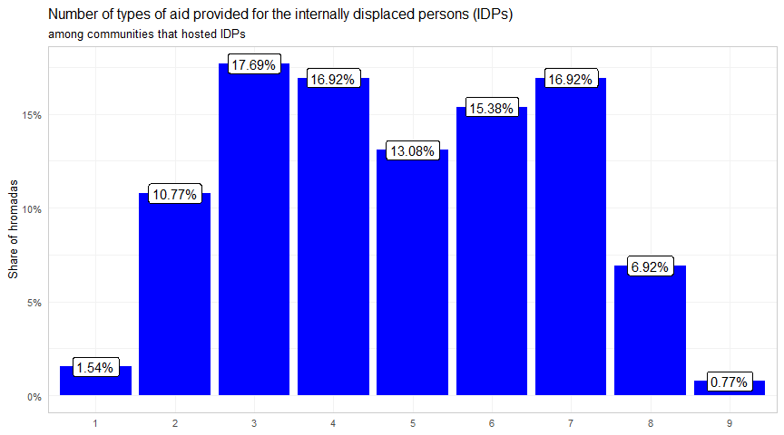

```r
ds0 %>%
  count(idp_help_count) %>%
  filter(!is.na(idp_help_count)) %>%
  mutate(freq = n/sum(n)) %>%
  ggplot(aes(x = factor(idp_help_count), y = freq)) +
  geom_bar(stat = "identity", fill = "blue") +
  geom_label(aes(label = scales::percent(freq)))  +
  scale_y_continuous(labels = scales::percent) +
  labs(
    title = "Number of types of aid provided for the internally displaced persons (IDPs)"
    ,subtitle = "among communities that hosted IDPs"
    ,y = "Share of hromadas", x = NULL, fill = NULL
  )
```

```r
help_idp_levels <- c('communal_placement', 'private_placement', 'regular_meal', 'humanitar_help',
                     'fundraising', "employ", "psych_help", "law_help", "transit_center")

d <- ds0 %>% select(hromada_code, voluntary_fct, starts_with('idp_help/'), -ends_with('number')) %>%
  pivot_longer(-c(hromada_code, voluntary_fct), names_to = 'help', values_to = 'count') %>%
  count(help, voluntary_fct, count) %>%
  group_by(help, voluntary_fct) %>%
  mutate(freq = n/sum(n),
         help = str_remove(help, 'idp_help/')) %>%
  filter(count == 1)

p <- d %>%
  ggplot(aes(x = fct_reorder(factor(help), freq, .desc = TRUE), y = freq, fill = voluntary_fct)) +
  geom_col(position = position_dodge())+
  geom_text(aes(label = scales::percent(freq, 1)), hjust = .4,
             vjust = -.3, position = position_dodge(width = .9), size = 3.2) +
  theme_bw() +
  theme(axis.title.y = element_blank(),
        axis.title.x = element_blank(),
        axis.text.x = element_text(size = 7)) +
  labs(title = 'Which actions or resources were effectively provided by the community \nfor internally displaced persons (IDPs)?',
       subtitle = "excluding occupied hromadas",
       fill = NULL) +
  scale_y_continuous(labels = scales::percent) +
  scale_x_discrete(labels=c('communal_placement' = "Placement of IDPs in \ncommunal or \nstate-owned \npremises",
                            'private_placement' = "Placement of IDPs in \nprivate premises",
                            'regular_meal' = "Regular \nmeal",
                            'humanitar_help' = "Issuance of \nhumanitarian \naid",
                            'fundraising' = "Fundraising for \nthe needs of IDPs",
                            "employ" = "Employment \nprograms \nin the community",
                            "psych_help" = "Psychological \nsupport for IDPs",
                            "law_help" = "Legal \nsupport for IDPs",
                            "transit_center" = "Organization of \na transit center")) +
  ggplot2::scale_fill_viridis_d(begin = 0, end = .8, direction = -1, option = "plasma",
                                guide= guide_legend(reverse=T))

p
```

[output not shown]

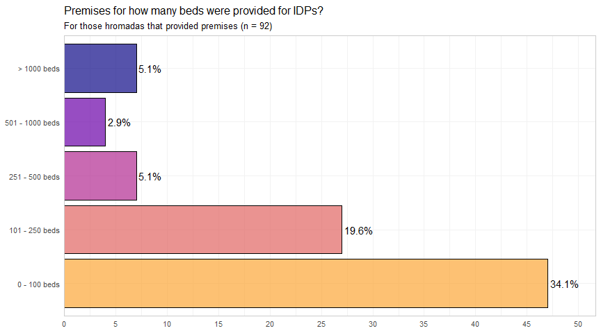

```r
d <- ds0 %>% select(idp_place_rooms)

(d %>% make_bi_freq_graph('idp_place_rooms')) +
  labs(
    title = "Premises for how many beds were provided for IDPs?",
    subtitle = "For those hromadas that provided premises (n = 92)"
    ,y = NULL, x = NULL, fill = NULL
  ) +
  scale_x_discrete(labels=c('0_100_beds' = "0 - 100 beds",
                            '101_250_beds' = "101 - 250 beds",
                            '251_500_beds' = "251 - 500 beds",
                            '501_1000_beds' = "501 - 1000 beds",
                            'over1000_beds' = "> 1000 beds")) +
  guides(fill = "none")
```

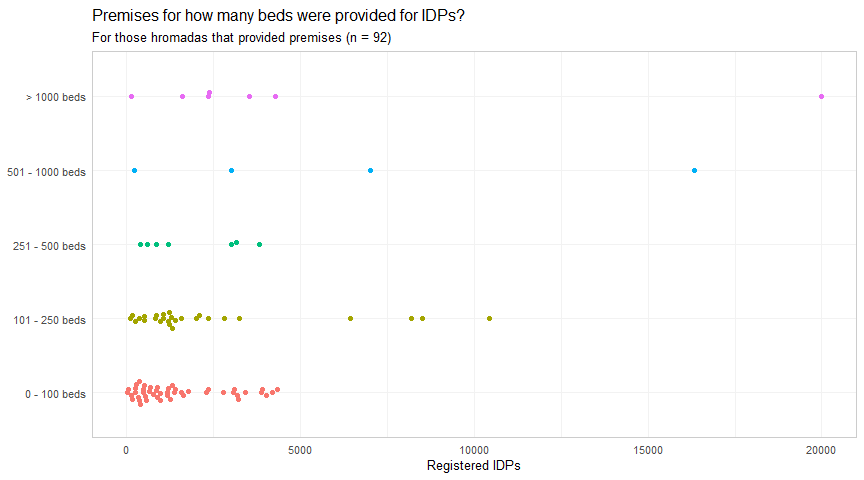

```r
d <- ds0 %>% filter(idp_accept == 'yes' & !is.na(idp_place_rooms)) %>%
  select(hromada_code, idp_registration_number, idp_place_rooms)

d %>%
  ggplot(aes(y = idp_place_rooms, x = idp_registration_number, color = idp_place_rooms)) +
  ggbeeswarm::geom_beeswarm() +
  scale_y_discrete(labels=c('0_100_beds' = "0 - 100 beds",
                            '101_250_beds' = "101 - 250 beds",
                            '251_500_beds' = "251 - 500 beds",
                            '501_1000_beds' = "501 - 1000 beds",
                            'over1000_beds' = "> 1000 beds")) +
  labs(title = "Premises for how many beds were provided for IDPs?",
       subtitle = "For those hromadas that provided premises (n = 92)",
       x = "Registered IDPs", y = NULL, color = NULL) +
  guides(color = "none")
```

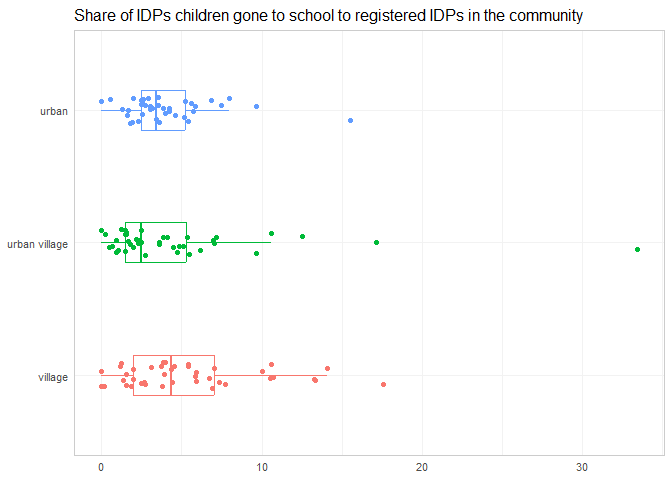

```r
d <- ds0 %>% filter(idp_accept == 'yes') %>%
  select(hromada_code, idp_child_share, type, occupation_and_combat_fct)

d %>%
  ggplot(aes(x = idp_child_share, y = type, col = type)) +
  geom_boxplot(width = .3, outlier.shape = NA) +
  geom_jitter(height = .1) +
  labs(title = "Share of IDPs children gone to school to registered IDPs in the community",
       x = NULL, y = NULL, color = NULL) +
  guides(color = "none")
```

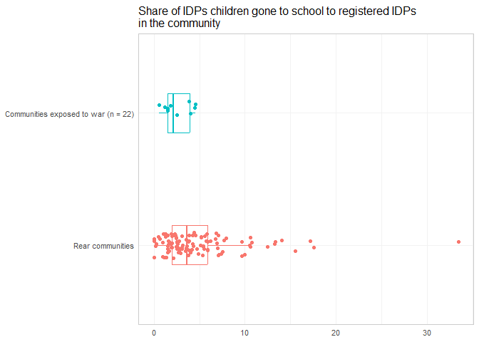

```r
d <- ds0 %>% filter(idp_accept == 'yes') %>%
  select(hromada_code, idp_child_share, type, occupation_and_combat_fct)

d %>%
  ggplot(aes(x = idp_child_share, y = occupation_and_combat_fct, col = occupation_and_combat_fct)) +
  geom_boxplot(width = .3, outlier.shape = NA) +
  geom_jitter(height = .1) +
  labs(title = "Share of IDPs children gone to school to registered IDPs \nin the community",
       x = NULL, y = NULL, color = NULL) +
  guides(color = "none")
```

# 8. Economics

> It has been observed that communities, both rear and war affected, mostly have not redirected their special fund expenditures to other needs.

> However, it was found that redirection of special fund was more frequent in rear communities, as opposed to war-exposed communities.

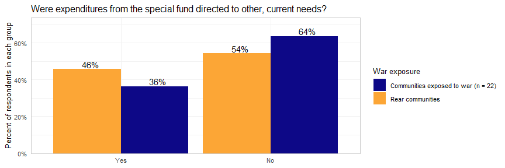

```r
d <- ds0 %>%
  mutate(
    spec_fund_relocation_fct = fct_recode(
      special_fund_relocation,
       "Yes"      = "yes"
      ,"No"       = "no"
    ) %>% factor( levels = c(
       "Yes"
       ,"No"
    )
    )
  )

d %>%
  group_by(spec_fund_relocation_fct,occupation_and_combat_fct) %>%
  summarize(
    hromada_count = n_distinct(hromada_code)
    ,.groups = "drop"
  ) %>%
  group_by(occupation_and_combat_fct) %>%
  mutate(
    prop = hromada_count/sum(hromada_count)
    ,pct = scales::percent(prop, accuracy = 1)
  ) %>%
  ggplot(aes(y=prop, x = spec_fund_relocation_fct, fill = occupation_and_combat_fct))+
  geom_col(position = position_dodge())+
  geom_text(aes(label = pct), hjust = .3, vjust = -.2, position = position_dodge(width = .9))+
  scale_y_continuous(labels = scales::percent_format(),expand = expansion(add = c(0,.1)))+
  ggplot2::scale_fill_viridis_d(begin = 0, end = .8, direction = -1, option = "plasma",guide= guide_legend(reverse=T))+
  labs(
    title = "Were expenditures from the special fund directed to other, current needs?"
    ,fill = "War exposure"
    ,y = "Percent of respondents in each group"
    ,x = NULL
  )
```

> Hromadas with higher level of fiscal self-sufficiency were less likely to redirect special funds for urgent needs.

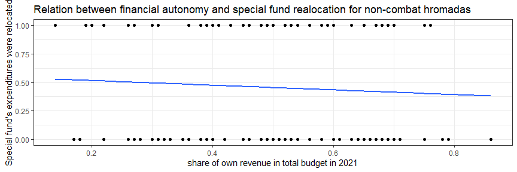

```r
(ds0 %>% filter(military_action=="no_combat") %>%
  mutate(
    `Special fund's expenditures were relocated` = case_when(special_fund_relocation=="no"~0,
                                                             special_fund_relocation=="yes"~1)
  ) %>%
  ggplot(aes(x = own_income_prop_2021, y = `Special fund's expenditures were relocated`)) +
  geom_point() +
  geom_smooth(method = "lm", se=F) +
  theme_bw() +
  labs(title = 'Relation between financial autonomy and special fund realocation for non-combat hromadas') +
  xlab("share of own revenue in total budget in 2021"))
```

> The most frequently mentioned sectors for the fund to be redirected to were Defense, Utilities, Social protection and Education - these are the most likely to challenge local authorities due to war shocks.

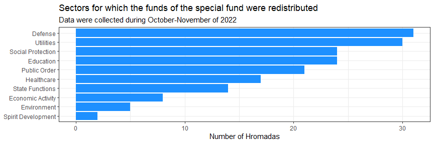

```r
ds0 %>%
  filter(special_fund_relocation == "yes") %>%
  select(hromada_name, `special_fund_relocation_needs/state_functions`:`special_fund_relocation_needs/healthcare`) %>%
  pivot_longer(-c(hromada_name), names_to = "sector", values_to = "cut") %>%
  mutate(
    sector = str_to_title(str_remove(sector, "sectors_"))
  ) %>%
  group_by(sector) %>%
  summarise(`Number of Hromadas` = sum(cut), .groups = "drop") %>%
  filter(`Number of Hromadas` > 0)  %>%
 mutate(sector = case_when(sector=="Special_fund_relocation_needs/Defense"~"Defense",
                           sector=="Special_fund_relocation_needs/Economic_activity"~"Economic Activity",
                           sector=="Special_fund_relocation_needs/Education"~"Education",
                           sector=="Special_fund_relocation_needs/Environment"~"Environment",
                           sector=="Special_fund_relocation_needs/Healthcare"~"Healthcare",
                           sector=="Special_fund_relocation_needs/Social_protection"~"Social Protection",
                           sector=="Special_fund_relocation_needs/Spirit_development"~"Spirit Development",
                           sector=="Special_fund_relocation_needs/State_functions"~"State Functions",
                           sector=="Special_fund_relocation_needs/Utilities"~"Utilities",
                           sector=="Special_fund_relocation_needs/Public_order"~"Public Order",
                           TRUE~sector)
 ) %>%
  ggplot(aes(x = `Number of Hromadas`, y = fct_reorder(sector, `Number of Hromadas`))) +
  geom_bar(stat = "identity") +
  theme_bw()+
  labs(
    title = "Sectors for which the funds of the special fund were redistributed"
    ,subtitle = "Data were collected during October-November of 2022"
    ,y = NULL
  )+
  geom_col(position = position_stack()
           , fill = "dodgerblue"
  )
```

> Hromadas did not report mass business relocation (every third mentioned no relocated companies at all). However, the most frequent destinations for relocation were naturally Western regions - Volyn, Invano-Frankivsk, Lviv, and Zakarpattia regions.

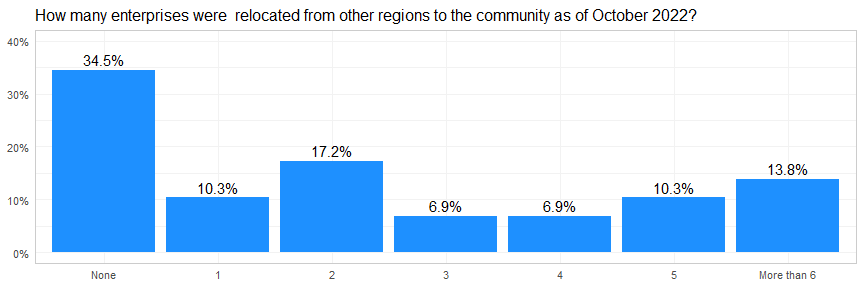

```r
d <- ds0 %>%
  select(relocated_companies_text) %>%
  mutate(relocated_companies = as.numeric(relocated_companies_text),
         relocated_companies_group = cut(relocated_companies,
                              breaks = c(0, 1, 2, 3, 4, 5, 6, 7, 100),
                              labels = c('None', '1', '2', '3', "4", "5", "6", "More than 6"),
                              right = T)) %>%
  na.omit()

d %>%
  ggplot(aes(x=relocated_companies_group, group = 1)) +
  geom_bar(aes(y = ..prop..), stat = 'count', fill = "dodgerblue") +
  geom_text(aes(label = scales::percent(..prop..), y = ..prop..), stat = 'count', vjust = -.4) +
  scale_y_continuous(labels = scales::percent_format(), limits = c(0, 0.4)) +
  labs(
    title = "How many enterprises were  relocated from other regions to the community as of October 2022?"
    ,y = NULL, x = NULL
  )
```

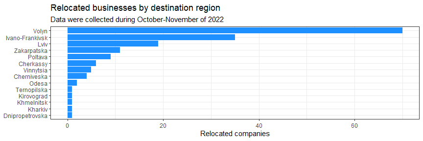

```r
ds0 %>%
  mutate(relocated_companies = as.numeric(relocated_companies_text)) %>%
      group_by(region_en,  oblast_name_en) %>%
      summarize(`Relocated companies` = sum(relocated_companies, na.rm = TRUE)) %>%
  filter(`Relocated companies`>0) %>%
    ggplot(aes(x = `Relocated companies`, y = fct_reorder(oblast_name_en, `Relocated companies`))) +
  geom_bar(stat = "identity") +
  theme_bw()+
  labs(
    title = "Relocated businesses by destination region"
    ,subtitle = "Data were collected during October-November of 2022"
    ,y = NULL
  )+
  geom_col(position = position_stack()
           , fill = "dodgerblue"
  )
```

> There is also a positive relation between fiscal autonomy and the number of relocated businesses.

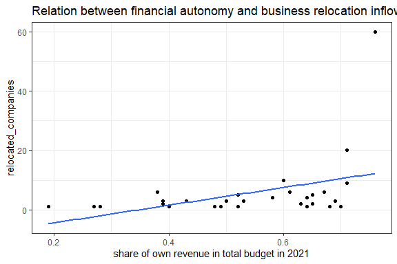

```r
ds0 %>%
  mutate(relocated_companies = as.numeric(relocated_companies_text)) %>%
  filter(relocated_companies>0) %>%
    ggplot(aes(y = relocated_companies, x = own_income_prop_2021 )) +
  geom_point() +
  geom_smooth(method = "lm", se=F) +
  theme_bw() +
  labs(title = 'Relation between financial autonomy and business relocation inflow') +
  xlab("share of own revenue in total budget in 2021")
```

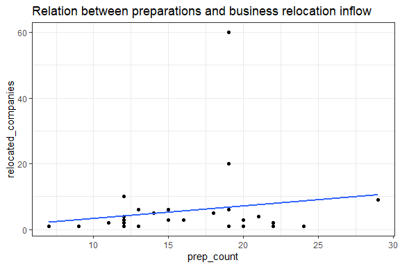

```r
ds0 %>% filter(military_action=="no_combat") %>%
  mutate(relocated_companies = as.numeric(relocated_companies_text)) %>%
  filter(relocated_companies>0) %>%
    ggplot(aes(y = relocated_companies, x = prep_count )) +
  geom_point() +
  geom_smooth(method = "lm", se=F) +
  theme_bw() +
  labs(title = 'Relation between preparations and business relocation inflow')
```

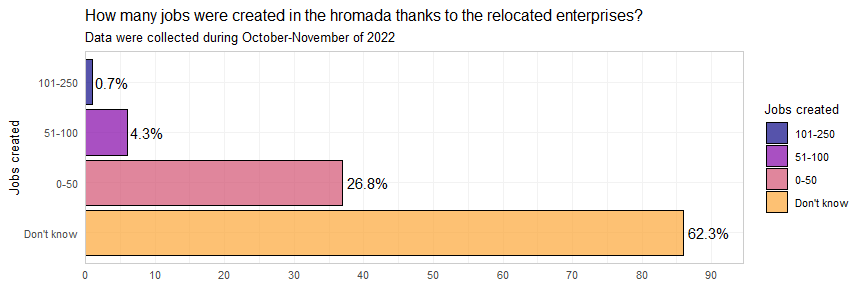

```r
(ds0 %>%
   mutate(
    `Jobs created` = fct_recode(
      created_jobs,
       "Don't know" = "dk",
      "0-50" = "0_50_jobs",
      "51-100" = "51_100_jobs",
      "101-250" = "101_250_jobs"
    ) %>% factor( levels = c(
       "Don't know"
       ,"0-50" ,
       "51-100",
       "101-250"
    )
    )
  ) %>%
   make_bi_freq_graph("Jobs created"))+
  labs(
    title = "How many jobs were created in the hromada thanks to the relocated enterprises?"
    ,subtitle = "Data were collected during October-November of 2022"
    ,y = NULL
  )
```

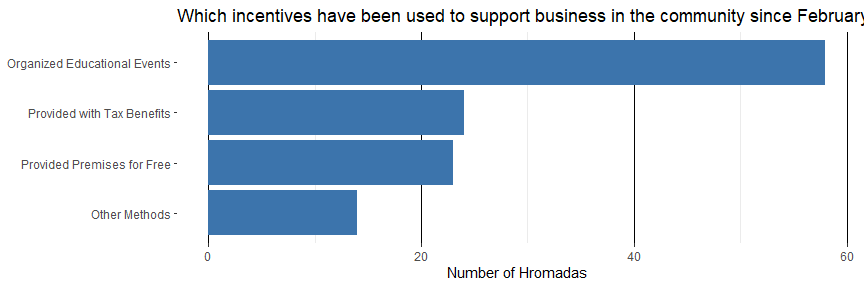

```r
ds0 %>% filter(bussiness_stimules_none == 0) %>%
  select(hromada_name, `bussiness_stimules/tax_benefits`:`bussiness_stimules/other`) %>%
  pivot_longer(-c(hromada_name), names_to = "type", values_to = "done") %>%
  mutate(
    type = str_to_title(str_remove(type, "types_"))
  ) %>%
  group_by(type) %>%
  summarise(`number of hromadas` = sum(done), .groups = "drop") %>%
  filter(`number of hromadas`>0) %>%
  mutate(type = case_when(type == "Bussiness_stimules/Education" ~ "Organized Educational Events",
                          type == "Bussiness_stimules/Free_rooms" ~ "Provided Premises for Free",
                          type == "Bussiness_stimules/Tax_benefits" ~ "Provided with Tax Benefits",
                          type == "Bussiness_stimules/Other" ~ "Other Methods",
  TRUE~type)
  ) %>%
  ggplot(aes(x = `number of hromadas`, y = fct_reorder(type, `number of hromadas`))) +
  geom_bar(stat = "identity", fill = "dodgerblue") +
  theme_bw()+
  geom_col(position = position_stack()
           , alpha = .5
           ,data =
  )+
  labs(
    title = "Which incentives have been used to support business in the community since February 24?"
    ,x = "Number of Hromadas", y = NULL, fill = NULL
  )+
  theme(
    panel.grid.major.y  = element_blank()
    ,panel.border = element_blank()
    ,panel.grid.major.x = element_line(color = "black")
  )
```

# 9. Humanitarian

> Too few answers to analyze - only 6

# 10. Reconstruction

> There are 38 communities (28% of all respondents) that had destructions from the hostilities.

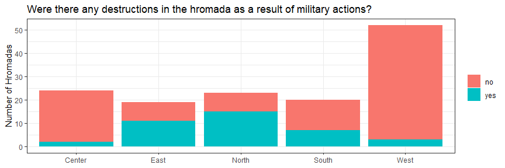

```r
ds0 %>%
  count(region_en, is_damaged) %>%
  ggplot(aes(x = region_en, y = n, fill = is_damaged)) +
  geom_bar(stat = "identity") +
  labs(
    title = "Were there any destructions in the hromada as a result of military actions?"
    ,y = "Number of Hromadas", x = NULL, fill = NULL
  ) +
  theme_bw()
```

> However, most of damaged hromadas report not mass destruction of housing of up to 10% - 20% of all respondents.

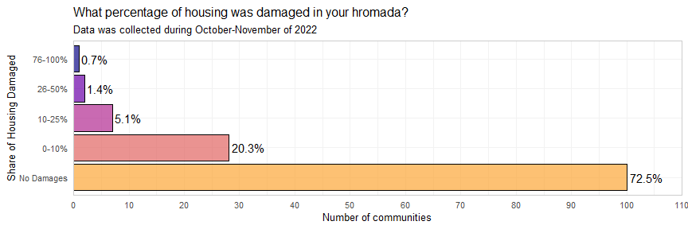

```r
(ds0 %>%
   mutate(
    `Share of Housing Damaged` = as.factor(case_when(
       is_damaged == "no" ~ "No Damages",
      percent_damaged== "0_10_percent" ~ "0-10%",
      percent_damaged== "10_25_percent" ~ "10-25%",
      percent_damaged== "26_50_percent" ~ "26-50%",
      percent_damaged== "50_75_percent" ~ "50-75%",
      percent_damaged== "76_100_percent" ~ "76-100%"
    )) %>% factor( levels = c(
       "No Damages"
       ,"0-10%" ,
       "10-25%",
       "26-50%",
       "50-75%",
       "76-100%"
    )
    )
  ) %>%
   make_bi_freq_graph("Share of Housing Damaged"))+
  labs(
    title = "What percentage of housing was damaged in your hromada?"
    ,subtitle = "Data was collected during October-November of 2022"
    ,y = "Number of communities", fill = NULL
  ) +
  guides(fill = "none")
```

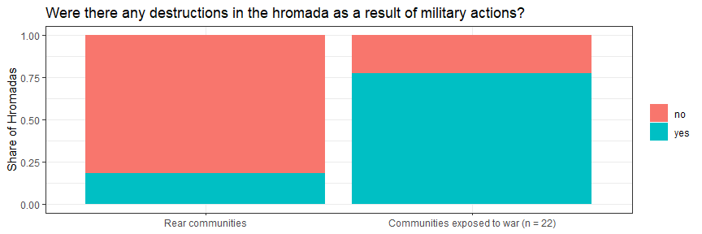

```r
ds0 %>%
  count(occupation_and_combat_fct, is_damaged) %>%
  ggplot() +
  aes(x = occupation_and_combat_fct, y=n,
             fill = is_damaged) +
  geom_bar(position = "fill", stat = "identity") +
  labs(
    title = "Were there any destructions in the hromada as a result of military actions?"
    ,y = "Share of Hromadas", x = NULL, fill = NULL
  ) +
  theme_bw()
```

> On average, only half of hromadas with reported damages performed damage assesment for indivuduals and businesses. Less have done so for communal entities - only 38%.

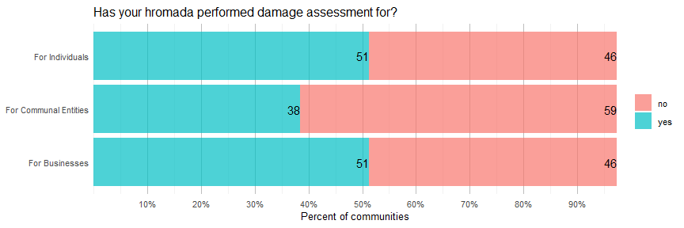

```r
d10 <-
  ds0 %>% filter(is_damaged == "yes") %>%
  pivot_longer(
    cols = c(damage_evaluation_persons, damage_evaluation_communal, damage_evaluation_bussiness)
    ,names_to = "type_of"
    ,values_to = "response"
  ) %>%
  group_by(type_of,response) %>%
  summarize(
    count = n_distinct(hromada_code)
    ,.groups = "drop"
  ) %>%
  group_by(type_of) %>%
  mutate(
    prop = count/sum(count, rm.na = T)
    ,pct = scales::percent(prop, accuracy = 1)
  ) %>%
  ungroup()  %>% mutate(type_of = case_when(type_of == "damage_evaluation_persons" ~ "For Individuals",
                                            type_of == "damage_evaluation_communal" ~ "For Communal Entities",
                                            type_of == "damage_evaluation_bussiness" ~ "For Businesses"))

g <-
  d10 %>%
  {
  ggplot(
    data = (.) %>% mutate(response=factor(response))
    ,aes(x=prop, y = type_of, fill=response)
  )+
  geom_col(position = position_stack()
           , alpha = .7
           ,data =
  )+
  geom_text(aes(label = str_remove(pct,"\\%"))
            ,hjust = 1
            , size = 4
            ,color="black"
            ,position = position_stack()
            ,data = .
            )+
  scale_x_continuous(
    breaks = seq(.1,1,.1)
    ,labels = scales::percent_format()
    ,expand = expansion(add=c(-.000,-.0))
  )+
  labs(
    title = "Has your hromada performed damage assessment for?"
    ,x = "Percent of communities", y = NULL, fill = NULL

  )+
  theme(
    # panel.grid = element_blank()
    panel.grid.major.y  = element_blank()
    ,panel.border = element_blank()
    ,panel.grid.major.x = element_line(color = "grey")
  )
  }

g
```

> Moreover, out of hromadas with damages (and which were not occupied), only every fourth has a Recovery plan.

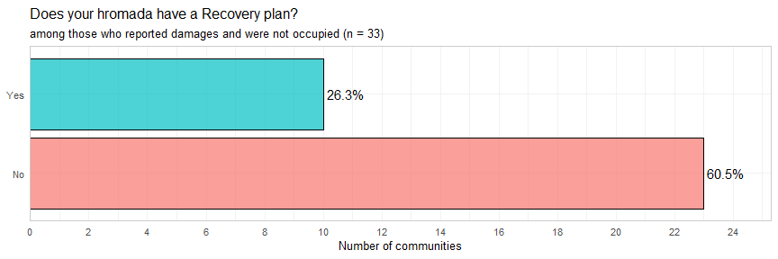

```r
(ds0 %>% mutate(`Does hromada have a Recovery plan?` = as.factor(case_when(reconstruction_plan=="yes"~"Yes",
                                                                reconstruction_plan=="no"~"No"
                                                                ))) %>% filter(is_damaged=="yes") %>% make_bi_freq_graph("Does hromada have a Recovery plan?")) +
  labs(
    title = "Does your hromada have a Recovery plan?"
    ,subtitle = "among those who reported damages and were not occupied (n = 33)"
    ,y = "Number of communities", x = NULL
  ) +
  scale_x_discrete(labels=c('TRUE' = 'Yes', 'FALSE' = 'No')) +
  scale_fill_discrete(labels=c('TRUE' = 'Yes', 'FALSE' = 'No')) +
  guides(fill = "none")
```

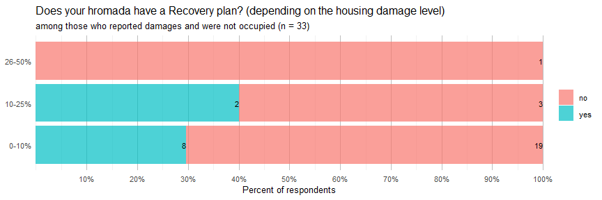

```r
ds13 <- ds0 %>% filter(!is.na(reconstruction_plan)) %>%
   mutate(
    `Share of Housing Damaged` = as.factor(case_when(
       is_damaged == "no" ~ "No Damages",
      percent_damaged== "0_10_percent" ~ "0-10%",
      percent_damaged== "10_25_percent" ~ "10-25%",
      percent_damaged== "26_50_percent" ~ "26-50%",
      percent_damaged== "50_75_percent" ~ "50-75%",
      percent_damaged== "76_100_percent" ~ "76-100%"
    )) %>% factor( levels = c(
       "No Damages"
       ,"0-10%" ,
       "10-25%",
       "26-50%",
       "50-75%",
       "76-100%"
    )
    )
  ) %>% filter(is_damaged == "yes") %>%
  group_by(`Share of Housing Damaged`, reconstruction_plan) %>%
  summarize(
    count = n()
    ,.groups = "drop"
  ) %>%
  ungroup() %>% group_by(`Share of Housing Damaged`) %>% mutate(
    prop = count/sum(count)
    ,pct = scales::percent(prop, accuracy = 1)
    )


g1 <-
  ds13 %>%
  {
  ggplot(
    data = (.)
    ,aes(x=prop, y = `Share of Housing Damaged`, fill=reconstruction_plan)
  )+
  geom_col(position = position_stack()
           , alpha = .7
           ,data =
  )+
  geom_text(aes(label = count)
            ,hjust = 1
            , size = 3
            ,color="black"
            ,position = position_stack()
            ,data = .
            )+
  scale_x_continuous(
    breaks = seq(.1,1,.1)
    ,labels = scales::percent_format()
    ,expand = expansion(add=c(-.000,-.0))
  )+
  labs(
    title = "Does your hromada have a Recovery plan? (depending on the housing damage level)"
    ,subtitle = "among those who reported damages and were not occupied (n = 33)"
    ,x = "Percent of respondents", y = NULL, fill = NULL

  )+
  theme(
    # panel.grid = element_blank()
    panel.grid.major.y  = element_blank()
    ,panel.border = element_blank()
    ,panel.grid.major.x = element_line(color = "grey")
  )
  }

g1
```

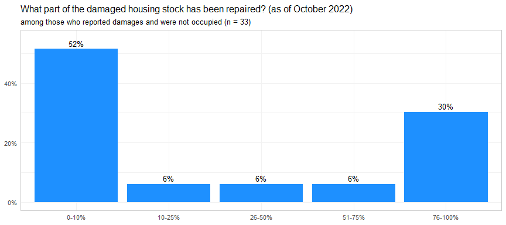

```r
p <- ds0 %>%
  select(percent_reconstructed) %>%
  na.omit() %>%
  ggplot(aes(x=percent_reconstructed, group = 1)) +
  geom_bar(aes(y = ..prop..), stat = 'count', fill = "dodgerblue") +
  geom_text(aes(label = scales::percent(..prop..), y = ..prop..), stat = 'count', vjust = -.4, size = 3.4) +
  scale_y_continuous(labels = scales::percent_format(), limits = c(0, 0.55)) +
  scale_x_discrete(labels=c('0_10_percent' = "0-10%",
                            '10_25_percent' = "10-25%",
                            '26_50_percent' = "26-50%",
                            '51_75_percent' = "51-75%",
                            '76_100_percent' = "76-100%")) +
  labs(
    title = "What part of the damaged housing stock has been repaired? (as of October 2022)",
    subtitle = "among those who reported damages and were not occupied (n = 33)"
    ,y = NULL, x = NULL
  )

p
```

```r
ds_projects_type <- ds0 %>%
  mutate(international_projects_number = as.numeric(international_projects)) %>%
  group_by(type) %>%
  summarise(median = median(international_projects_number, na.rm =  T),
            mean = mean(international_projects_number, na.rm =  T),
            max = max(international_projects_number, na.rm =  T))

ds_projects_war <- ds0 %>%
  mutate(international_projects_number = as.numeric(international_projects)) %>%
  group_by(occupation_and_combat_fct) %>%
  summarise(median = median(international_projects_number, na.rm =  T),
            mean = mean(international_projects_number, na.rm =  T),
            max = max(international_projects_number, na.rm =  T))
```

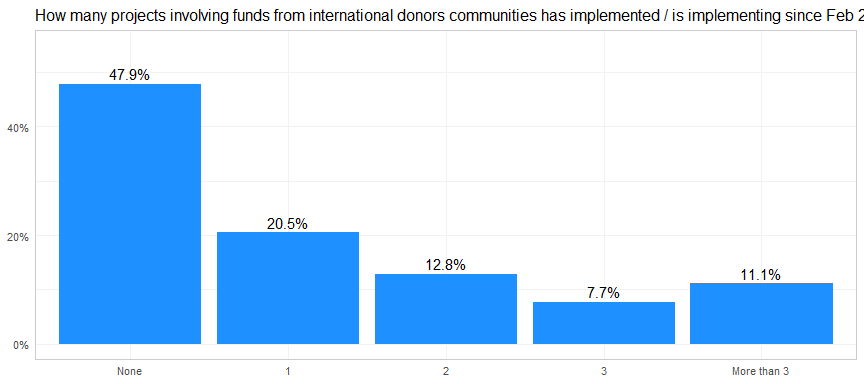

```r
d <- ds0 %>%
  mutate(international_projects_number = as.numeric(international_projects)) %>%
  select(hromada_full_name, international_projects_number, type, occupation_and_combat_fct) %>%
  mutate(international_projects_group = cut(international_projects_number,
                              breaks = c(0, 1, 2, 3, 4, 20),
                              labels = c('None', '1', '2', '3', 'More than 3'),
                              right = F)) %>%
  na.omit()

p <- d %>%
  ggplot(aes(x=international_projects_group, group = 1)) +
  geom_bar(aes(y = ..prop..), stat = 'count', fill = "dodgerblue") +
  geom_text(aes(label = scales::percent(..prop..), y = ..prop..), stat = 'count', vjust = -.4) +
  scale_y_continuous(labels = scales::percent_format(), limits = c(0, 0.55)) +
  labs(
    title = "How many projects involving funds from international donors communities has implemented / is implementing since Feb 24?"
    ,y = NULL, x = NULL
  )

p
```

> These are hromadas in our survey that have the most implemented projects:

| Hromada Name | Number of projects |
| --- | --- |
| Тлумацька міська громада | 12 |
| Коломийська міська громада | 12 |
| Бобринецька міська громада | 9 |
| Покровська селищна громада | 7 |
| Прилуцька міська громада | 7 |
| Ясінянська селищна громада | 5 |
| Надвірнянська міська громада | 5 |
| Новороздільська міська громада | 5 |
| Лубенська міська громада | 5 |
| Тростянецька міська громада | 5 |
| Гусятинська селищна громада | 5 |

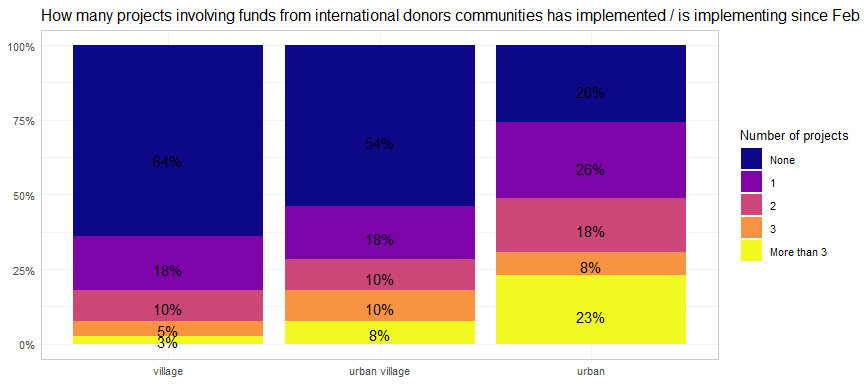

```r
d1 <- d %>% count(international_projects_group, type) %>%
  group_by(type) %>%
  mutate(prop = n/sum(n)
         ,pct = scales::percent(prop, accuracy = 1))

p <- d1 %>%
  ggplot() +
  aes(y = prop, x=type, fill = international_projects_group, label = pct) +
  geom_bar(stat = 'identity') +
  geom_text(position = position_fill(vjust = .4), size = 4) +
  scale_fill_viridis_d(option = "plasma") +
  scale_y_continuous(labels = scales::percent_format()) +
  labs(
    title = "How many projects involving funds from international donors communities has implemented / is implementing since Feb 24?"
    ,y = NULL, x = NULL, fill = "Number of projects"
  )

p
```

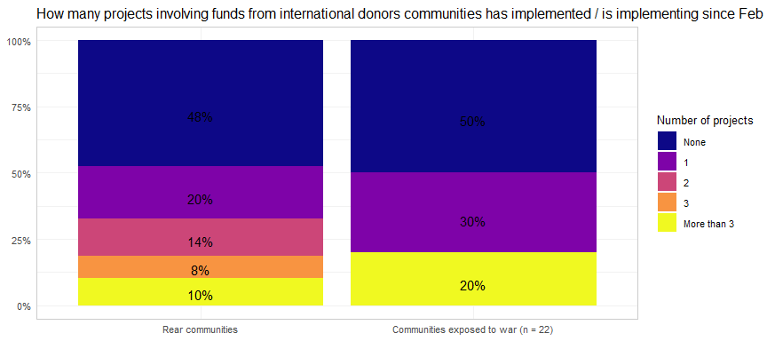

```r
d1 <- d %>% count(international_projects_group, occupation_and_combat_fct) %>%
  group_by(occupation_and_combat_fct) %>%
  mutate(prop = n/sum(n)
         ,pct = scales::percent(prop, accuracy = 1))

p <- d1 %>%
  ggplot() +
  aes(y = prop, x=occupation_and_combat_fct, fill = international_projects_group, label = pct) +
  geom_bar(stat = 'identity') +
  geom_text(position = position_fill(vjust = .4), size = 4) +
  scale_fill_viridis_d(option = "plasma") +
  scale_y_continuous(labels = scales::percent_format()) +
  labs(
    title = "How many projects involving funds from international donors communities has implemented / is implementing since Feb 24?"
    ,y = NULL, x = NULL, fill = "Number of projects"
  )

p
```

# 11. Current Challenges

> Only 19% communities have no spending on equipment/refurbishment of shelters for schools from the community budget.

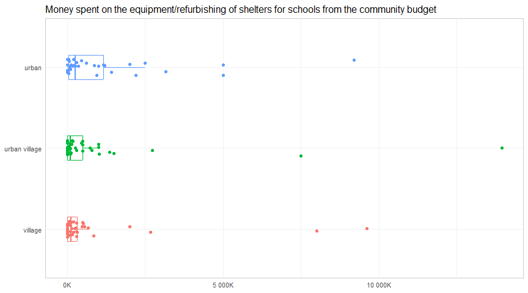

```r
d <- ds0 %>%
  select(hromada_code, finance_school_shelters_coded, type, occupation_and_combat_fct)

d %>%
  ggplot(aes(x = finance_school_shelters_coded, y = type, col = type)) +
  geom_boxplot(width = .3, outlier.shape = NA) +
  geom_jitter(height = .1) +
  scale_x_continuous(labels = scales::label_number(suffix = "K", scale = 1e-3)) +
  labs(title = "Money spent on the equipment/refurbishing of shelters for schools from the community budget",
       x = NULL, y = NULL, color = NULL) +
  guides(color = "none")
```

> The quality of answers for questions about missed school days since February 24th, including virtual learning, has been poor . However, half of the sample, 50.5%, haven’t missed any school days due to the switch to virtual learning.

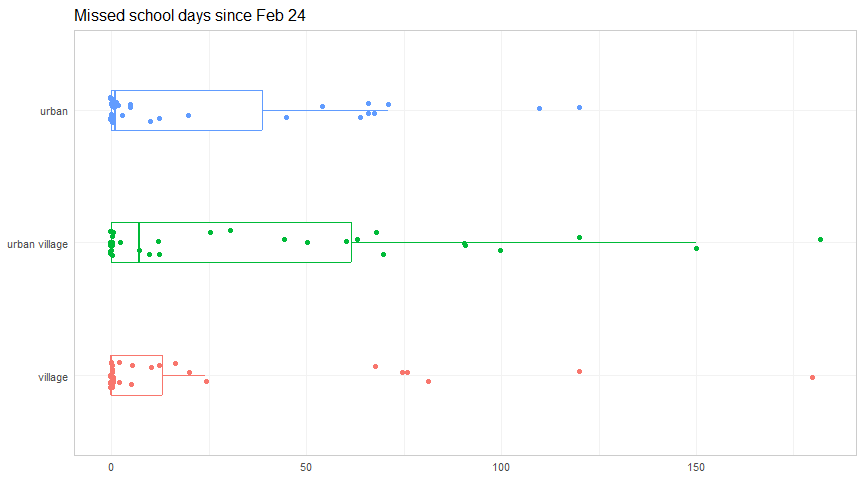

```r
d <- ds0 %>%
  select(hromada_code, no_school_days_coded, type) %>%
  mutate(no_school_days_coded = as.numeric(no_school_days_coded))

d %>%
  ggplot(aes(x = no_school_days_coded, y = type, color = type)) +
  geom_boxplot(width = .3, outlier.shape = NA) +
  geom_jitter(height = .1) +
  labs(title = "Missed school days since Feb 24",
       x = NULL, y = NULL, color = NULL) +
  guides(color = "none")
```

## 11.1 Heating season

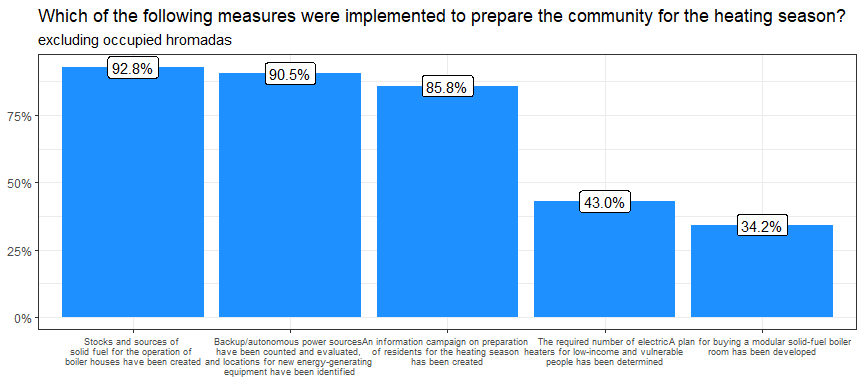

```r
d <- ds1_winter_prep %>%
  select(hromada_name, all_of(prep_for_winter)) %>%
  pivot_longer(
    -hromada_name
    ,names_to = "action"
    ,values_to = "response"
  ) %>%
  group_by(action) %>%
  summarise(n = sum(response, na.rm = T), .groups = "drop", na = sum(!is.na(response))) %>%
  mutate(freq = n/na)

d %>%
  ggplot(aes(y = freq, x = fct_reorder(action, freq, .desc = T))) +
  geom_col(fill = "dodgerblue") +
  geom_label(aes(label = scales::percent(freq)))  +
  theme_bw() +
  theme(axis.title.y = element_blank(),
        axis.title.x = element_blank(),
        axis.text.x = element_text(size = 7)) +
  labs(title = 'Which of the following measures were implemented to prepare the community for the heating season?',
       subtitle = "excluding occupied hromadas",) +
  scale_y_continuous(labels = scales::percent) +
  scale_x_discrete(labels=c('reserves' = "Stocks and sources of \nsolid fuel for the operation of \nboiler houses have been created",
                            'info_campaign' = "An information campaign on preparation \nof residents for the heating season \nhas been created",
                            'count_power_sources' = "Backup/autonomous power sources \nhave been counted and evaluated, \nand locations for new energy-generating \nequipment have been identified",
                            'count_heaters_need' = "The required number of electric \nheaters for low-income and vulnerable \npeople has been determined",
                            'solid_fuel_boiler' = "A plan for buying a modular solid-fuel boiler \nroom has been developed")
                   )
```

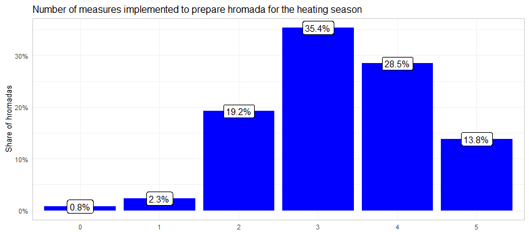

```r
ds1_winter_prep %>%
  count(winter_prep_count) %>%
  filter(!is.na(winter_prep_count)) %>%
  mutate(freq = n/sum(n)) %>%
  ggplot(aes(x = factor(winter_prep_count), y = freq)) +
  geom_bar(stat = "identity", fill = "blue") +
  geom_label(aes(label = scales::percent(freq)))  +
  scale_y_continuous(labels = scales::percent) +
  labs(
    title = "Number of measures implemented to prepare hromada for the heating season"
    ,y = "Share of hromadas", x = NULL, fill = NULL
  )
```

## 11.2 Problem Involvement

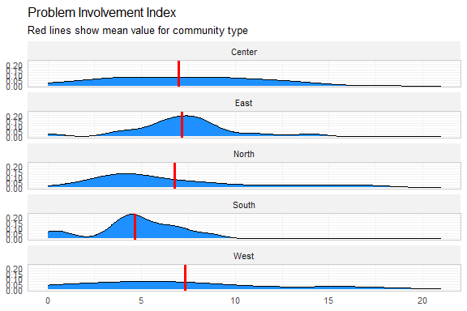

```r
d <- ds1_problem %>%
  select(hromada_code, problem_additive_index, region_en)

d_mean <- ds1_problem %>%
  group_by(region_en) %>%
  summarise(mean = mean(problem_additive_index, na.rm = T))


d %>%
  ggplot(aes(x = problem_additive_index)) +
  geom_density(fill="dodgerblue") +
  facet_wrap(region_en ~ ., nrow = 5) +
  geom_vline(data = d_mean, aes(xintercept = mean), color = "red", lwd = 1.2) +
  labs(title = "Problem Involvement Index",
       subtitle = "Red lines show mean value for community type",
       x = NULL, y = NULL, color = NULL) +
  guides(color = "none")
```

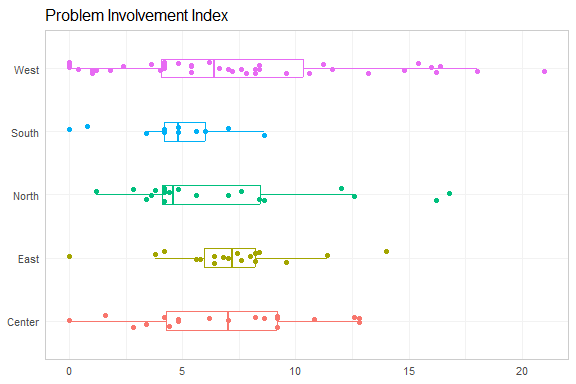

```r
d %>%
  ggplot(aes(x = problem_additive_index, y = region_en, color = region_en)) +
  geom_boxplot(width = .3, outlier.shape = NA) +
  geom_jitter(height = .1) +
  labs(title = "Problem Involvement Index",
       x = NULL, y = NULL, color = NULL) +
  guides(color = "none")
```

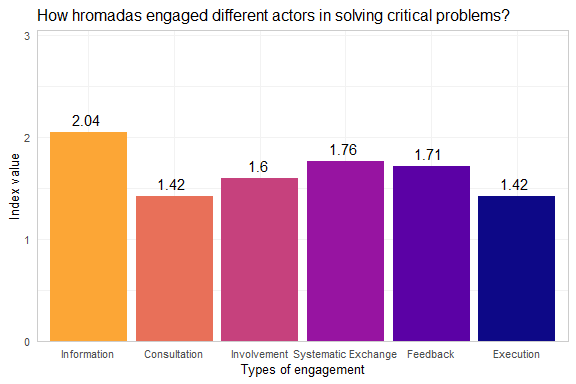

```r
d <- ds1_problem %>% select(contains('index'), region_en, hromada_code,
                            occupation_and_combat_fct, -index) %>%
  pivot_longer(-c(region_en, occupation_and_combat_fct, hromada_code),
               names_to = 'engagement', values_to = 'index')

ds1_problem %>% select(contains('index'), -index, -problem_additive_index) %>%
  summarise(across(everything(.), ~mean(.x, na.rm = T))) %>%
  mutate(group = "all") %>%
  pivot_longer(-group, names_to = 'engagement', values_to = "index") %>%
  mutate(engagement = factor(engagement,
                             levels = c('problem_info_index', 'problem_consultation_index',
                                        'problem_proposition_index', 'problem_system_index',
                                        'problem_feedback_index', 'problem_execution_index'))) %>%
  ggplot(aes(x = engagement, y = index, fill = engagement)) +
    geom_col()+
    geom_text(aes(label = round(index, 2)), hjust = .6, vjust = -.6) +
    scale_y_continuous(expand = expansion(add = c(0,1))) +
    scale_x_discrete(labels=c('problem_info_index' = "Information",
                              'problem_consultation_index' = "Consultation",
                              'problem_proposition_index' = "Involvement",
                              'problem_system_index' = "Systematic Exchange",
                              'problem_feedback_index' = "Feedback",
                              'problem_execution_index' = "Execution")) +
    scale_fill_viridis_d(begin = 0, end = .8, direction = -1,
                                  option = "plasma",guide= guide_legend(reverse=T))+
  labs(
    title = "How hromadas engaged different actors in solving critical problems?"
    ,fill = NULL
    ,x = "Types of engagement"
    , y = "Index value"
  ) +
  guides(fill = "none")
```

# 12. Deoccupied hromadas

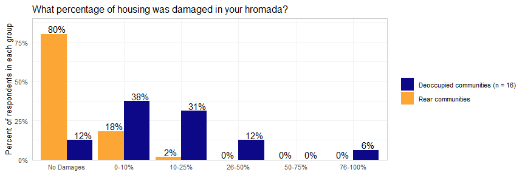

```r
d <- ds0 %>%
   filter(!is.na(occupation)) %>%
   mutate(
    `Share of Housing Damaged` = as.factor(case_when(
       is_damaged == "no" ~ "No Damages",
      percent_damaged== "0_10_percent" ~ "0-10%",
      percent_damaged== "10_25_percent" ~ "10-25%",
      percent_damaged== "26_50_percent" ~ "26-50%",
      percent_damaged== "50_75_percent" ~ "50-75%",
      percent_damaged== "76_100_percent" ~ "76-100%"
    )) %>% factor( levels = c(
       "No Damages"
       ,"0-10%" ,
       "10-25%",
       "26-50%",
       "50-75%",
       "76-100%"
    ))) %>%
  group_by(`Share of Housing Damaged`,occupation_fct, .drop = F) %>%
  summarize(
    hromada_count = n_distinct(hromada_code)
    ,.groups = "drop") %>%
  group_by(occupation_fct) %>%
  mutate(
    prop = hromada_count/sum(hromada_count)
    ,pct = scales::percent(prop, accuracy = 1)
  )

g <- d %>%
  ggplot(aes(y=prop, x = `Share of Housing Damaged`, fill = occupation_fct))+
  geom_col(position = position_dodge())+
  geom_text(aes(label = pct), hjust = .3, vjust = -.2, position = position_dodge(width = .9))+
  scale_y_continuous(labels = scales::percent_format(),expand = expansion(add = c(0,.1)))+
  ggplot2::scale_fill_viridis_d(begin = 0, end = .8, direction = -1, option = "plasma",guide= guide_legend(reverse=T))+
  labs(
    title = "What percentage of housing was damaged in your hromada?"
    ,fill = NULL
    ,y = "Percent of respondents in each group"
    ,x = NULL
  )

g
```

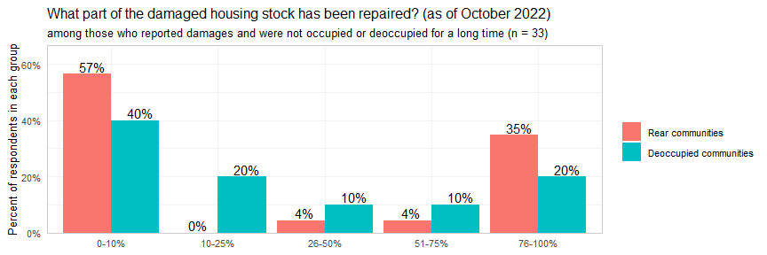

```r
d <- ds0 %>%
   filter(!is.na(occupation) & !is.na(percent_reconstructed)) %>%
  group_by(percent_reconstructed,occupation_fct, .drop = F) %>%
  summarize(
    hromada_count = n_distinct(hromada_code)
    ,.groups = "drop") %>%
  group_by(occupation_fct) %>%
  mutate(
    prop = hromada_count/sum(hromada_count)
    ,pct = scales::percent(prop, accuracy = 1)
  )

g <- d %>%
  ggplot(aes(y=prop, x = percent_reconstructed, fill = occupation_fct))+
  geom_col(position = position_dodge())+
  geom_text(aes(label = pct), hjust = .3, vjust = -.2, position = position_dodge(width = .9))+
  scale_y_continuous(labels = scales::percent_format(),expand = expansion(add = c(0,.1)))+
  ggplot2::scale_fill_viridis_d(begin = 0, end = .8, direction = -1, option = "plasma",guide= guide_legend(reverse=T))+
  scale_fill_discrete(labels = c("Rear communities",
                                 "Deoccupied communities")) +
    scale_x_discrete(labels=c('0_10_percent' = "0-10%",
                            '10_25_percent' = "10-25%",
                            '26_50_percent' = "26-50%",
                            '51_75_percent' = "51-75%",
                            '76_100_percent' = "76-100%")) +
  labs(
    title = "What part of the damaged housing stock has been repaired? (as of October 2022)"
    ,subtitle = "among those who reported damages and were not occupied or deoccupied for a long time (n = 33)"
    ,fill = NULL
    ,y = "Percent of respondents in each group"
    ,x = NULL
  )

g
```

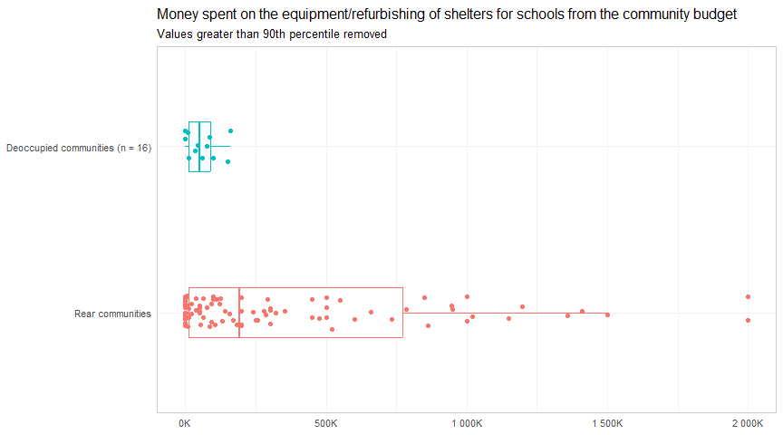

```r
d <- ds0 %>%
  select(hromada_code, finance_school_shelters_coded, occupation_fct) %>%
  mutate(finance_school_shelters_coded = as.numeric(finance_school_shelters_coded))

g <- d %>%
  filter(!is.na(finance_school_shelters_coded)) %>%
  ggplot(aes(x = finance_school_shelters_coded, y = occupation_fct, color = occupation_fct)) +
  geom_boxplot(width = .3, outlier.shape = NA) +
coord_cartesian(xlim = quantile(d$finance_school_shelters_coded, c(0, 0.9), na.rm = T)) +
  scale_x_continuous(labels = scales::label_number(suffix = "K", scale = 1e-3)) +
  geom_jitter(height = .1) +
  labs(title = "Money spent on the equipment/refurbishing of shelters for schools from the community budget",
       subtitle = "Values greater than 90th percentile removed",
       x = NULL, y = NULL, color = NULL) +
  guides(color = "none")

g
```

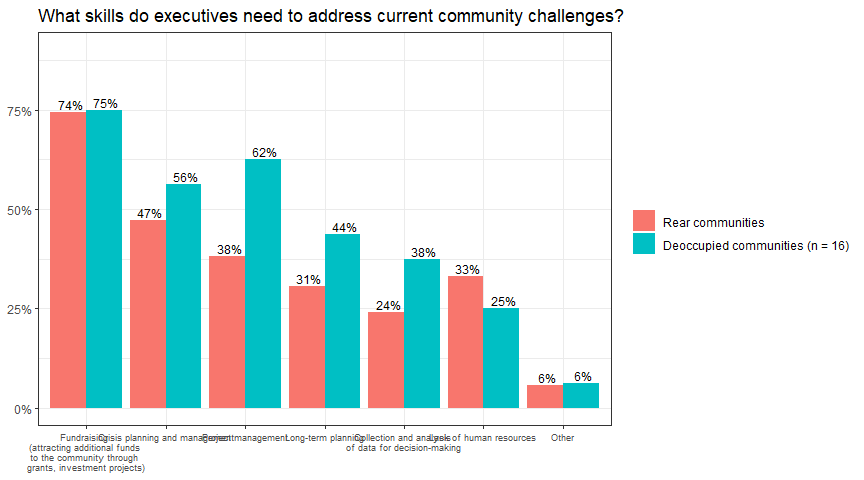

```r
d <- ds0 %>%
  filter(!is.na(occupation)) %>%
  select(hromada_name, occupation_fct, all_of(skills)) %>%
  pivot_longer(
    -c(hromada_name,occupation_fct)
    ,names_to = "action"
    ,values_to = "response"
  ) %>%
  group_by(action, occupation_fct) %>%
  summarise(n = sum(response, na.rm = T), .groups = "drop", na = sum(!is.na(response))) %>%
  mutate(freq = n/na)

g <- d %>%
  ggplot(aes(y = freq, x = fct_reorder(action, freq, .desc = T), fill = occupation_fct)) +
  geom_col(position = position_dodge())+
  geom_text(aes(label = scales::percent(freq, 1)), hjust = .4,
             vjust = -.3, position = position_dodge(width = .9), size = 3.2) +
  theme_bw() +
  theme(axis.title.y = element_blank(),
        axis.title.x = element_blank(),
        axis.text.x = element_text(size = 7)) +
  labs(title = 'What skills do executives need to address current community challenges?',
       fill = NULL) +
  scale_y_continuous(labels = scales::percent, limits = c(0, 0.9)) +
  scale_x_discrete(labels=c('skills_needed/fundraising' = "Fundraising \n(attracting additional funds \nto the community through \ngrants, investment projects)",
                            'skills_needed/project_management' = "Project management",
                            'skills_needed/longterm_planning' = "Long-term planning",
                            'skills_needed/crisis_planning' = "Crisis planning and management",
                            'skills_needed/data_analysis' = "Collection and analysis \nof data for decision-making",
                            "skills_needed/human_resourse" = "Lack of human resources",
                            "skills_needed/other" = "Other")
                   )

g
```

```r
meta_survey %>% filter(group=="preparation") %>% pull(name)
```

```
 [1] "prep_first_aid_water"            "prep_first_aid_fuel"
 [3] "prep_reaction_plan"              "prep_evacuation_plan"
 [5] "prep_reaction_plan_oth_hromadas" "prep_reaction_plan_oda"
 [7] "prep_dftg_creation"              "prep_national_resistance"
 [9] "prep_starosta_meeting"           "prep_communal_meetiing"
[11] "prep_online_map"                 "prep_shelter_list"
[13] "prep_notification_check"         "prep_backup"
[15] "prep_partly_backup"
```

# Session Information

For the sake of documentation and reproducibility, the current report was rendered in the following environment. Click the line below to expand.

Report rendered by Valentyn Hatsko at 2023-02-15, 16:53 +0200 in 34 seconds.